# Excel Data Analysis with Python

#### This notebook describes a workflow for data analysis with Python and Excel. The purpose of this workflow is to prototype a method that can be extended to Excel to distribute to end users who aren't familiar with Python. This allows for more robust analysis with a ubiquitous front-end in Excel.

#### After doing the analysis, the code in the IPython Notebook would then be transferred to production in order to leverage packages that have more support for working with Excel. These include [xlwt, xlrd](http://www.python-excel.org/) and [Xlsxwriter](https://xlsxwriter.readthedocs.org/).

#### The following is based on the statsmodel ARMA model example with a different dataset.

## Getting Started

#### Load Pylab inline to view matplotlib charts

```python
%pylab inline
```

#### Import required libraries for analysis

```python
from __future__ import print_function
import numpy as np
import pandas as pd
from pandas import Series, DataFrame
from scipy import stats
import matplotlib.pyplot as plt
import statsmodels.api as sm
from IPython.display import Image
```

```python
from statsmodels.graphics.api import qqplot
```

#### xlwings is a Python library that allows interaction with Excel and IPython Notebooks. It has support for range, workbook and chart objects that can be read and written through a notebook. It is a new library so there isn't a whole lot of features, but it works great for prototyping interaction with Excel.

```python
from IPython.display import HTML
HTML('<iframe src=http://xlwings.org/ width=800 height=300></iframe>')
```

[interactive chart not shown]

#### Import xlwings and open a new Excel sheet. These must be placed in the same cell in order to load properly.

```python
from xlwings import Range, Workbook, Chart
wb = Workbook()
```

## Loading Data into Python and Excel

#### The dataset used is from R's standard dataset library. The datasets can be found on Github here: [R datasets](https://github.com/vincentarelbundock/Rdatasets). The data includes only 114 records, so our fit might not be that great. However, this will serve as a good introduction.

```python
lynx = pd.read_csv('D:\Google_Drive\Google_Drive\Projects\Datasets\Rdata\datasets\lynx.csv')
```

```python
lynx
```

|  | Unnamed: 0 | time | lynx |
| --- | --- | --- | --- |
| 0 | 1 | 1821 | 269 |
| 1 | 2 | 1822 | 321 |
| 2 | 3 | 1823 | 585 |
| 3 | 4 | 1824 | 871 |
| 4 | 5 | 1825 | 1475 |
| 5 | 6 | 1826 | 2821 |
| 6 | 7 | 1827 | 3928 |
| 7 | 8 | 1828 | 5943 |
| 8 | 9 | 1829 | 4950 |
| 9 | 10 | 1830 | 2577 |
| 10 | 11 | 1831 | 523 |
| 11 | 12 | 1832 | 98 |
| 12 | 13 | 1833 | 184 |
| 13 | 14 | 1834 | 279 |
| 14 | 15 | 1835 | 409 |
| 15 | 16 | 1836 | 2285 |
| 16 | 17 | 1837 | 2685 |
| 17 | 18 | 1838 | 3409 |
| 18 | 19 | 1839 | 1824 |
| 19 | 20 | 1840 | 409 |
| 20 | 21 | 1841 | 151 |
| 21 | 22 | 1842 | 45 |
| 22 | 23 | 1843 | 68 |
| 23 | 24 | 1844 | 213 |
| 24 | 25 | 1845 | 546 |
| 25 | 26 | 1846 | 1033 |
| 26 | 27 | 1847 | 2129 |
| 27 | 28 | 1848 | 2536 |
| 28 | 29 | 1849 | 957 |
| 29 | 30 | 1850 | 361 |
| 30 | 31 | 1851 | 377 |
| 31 | 32 | 1852 | 225 |
| 32 | 33 | 1853 | 360 |
| 33 | 34 | 1854 | 731 |
| 34 | 35 | 1855 | 1638 |
| 35 | 36 | 1856 | 2725 |
| 36 | 37 | 1857 | 2871 |
| 37 | 38 | 1858 | 2119 |
| 38 | 39 | 1859 | 684 |
| 39 | 40 | 1860 | 299 |
| 40 | 41 | 1861 | 236 |
| 41 | 42 | 1862 | 245 |
| 42 | 43 | 1863 | 552 |
| 43 | 44 | 1864 | 1623 |
| 44 | 45 | 1865 | 3311 |
| 45 | 46 | 1866 | 6721 |
| 46 | 47 | 1867 | 4254 |
| 47 | 48 | 1868 | 687 |
| 48 | 49 | 1869 | 255 |
| 49 | 50 | 1870 | 473 |
| 50 | 51 | 1871 | 358 |
| 51 | 52 | 1872 | 784 |
| 52 | 53 | 1873 | 1594 |
| 53 | 54 | 1874 | 1676 |
| 54 | 55 | 1875 | 2251 |
| 55 | 56 | 1876 | 1426 |
| 56 | 57 | 1877 | 756 |
| 57 | 58 | 1878 | 299 |
| 58 | 59 | 1879 | 201 |
| 59 | 60 | 1880 | 229 |
|  | ... | ... | ... |

114 rows × 3 columns

```python
lynx = lynx.drop(['Unnamed: 0', 'time'], axis=1)
```

```python
lynx.columns = ['Lynx Captures']
```

```python
lynx
```

|  | Lynx Captures |
| --- | --- |
| 0 | 269 |
| 1 | 321 |
| 2 | 585 |
| 3 | 871 |
| 4 | 1475 |
| 5 | 2821 |
| 6 | 3928 |
| 7 | 5943 |
| 8 | 4950 |
| 9 | 2577 |
| 10 | 523 |
| 11 | 98 |
| 12 | 184 |
| 13 | 279 |
| 14 | 409 |
| 15 | 2285 |
| 16 | 2685 |
| 17 | 3409 |
| 18 | 1824 |
| 19 | 409 |
| 20 | 151 |
| 21 | 45 |
| 22 | 68 |
| 23 | 213 |
| 24 | 546 |
| 25 | 1033 |
| 26 | 2129 |
| 27 | 2536 |
| 28 | 957 |
| 29 | 361 |
| 30 | 377 |
| 31 | 225 |
| 32 | 360 |
| 33 | 731 |
| 34 | 1638 |
| 35 | 2725 |
| 36 | 2871 |
| 37 | 2119 |
| 38 | 684 |
| 39 | 299 |
| 40 | 236 |
| 41 | 245 |
| 42 | 552 |
| 43 | 1623 |
| 44 | 3311 |
| 45 | 6721 |
| 46 | 4254 |
| 47 | 687 |
| 48 | 255 |
| 49 | 473 |
| 50 | 358 |
| 51 | 784 |
| 52 | 1594 |
| 53 | 1676 |
| 54 | 2251 |
| 55 | 1426 |
| 56 | 756 |
| 57 | 299 |
| 58 | 201 |
| 59 | 229 |
|  | ... |

114 rows × 1 columns

### Copy lynx data in Excel sheet starting at cell A1. As the data is set as a pandas DataFrame, the index column will be copied as well.

```python
Range('A1').value = lynx
```

```python
Image(url='http://www.aaronschlegel.com/wp-content/uploads/2014/06/insertdatatoexcel.png')
```

[figure not shown]

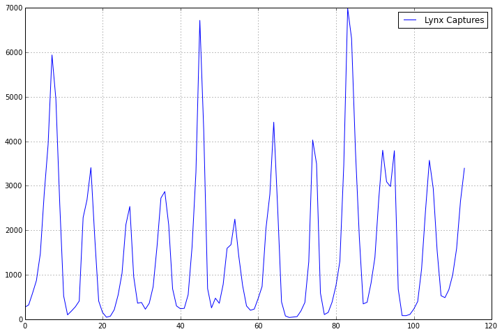

```python
lynx.plot(figsize=(12,8))
```

#### Create an Excel chart using the lynx data that was copied. Note: The chart created by xlwings defaults to a bar chart. From what I found, the only way right now to add data to a desired chart is to initialize blank chart in Excel and pass the name of the chart into the Chart() object.

```python
chart = Chart().add()
chart.set_source_data(Range('B2').vertical)
```

```python
Image(url='http://www.aaronschlegel.com/wp-content/uploads/2014/06/defaultxlwingschart.png')
```

[figure not shown]

### To add the data into a line chart, create the chart in Excel first and then pass the name it the Chart object

```python
Chart('Chart 2').set_source_data(Range('B2').vertical)
```

```python
Image(url='http://www.aaronschlegel.com/wp-content/uploads/2014/06/xlwingslinechart.png')
```

[figure not shown]

```python
lynx.index = pd.Index(sm.tsa.datetools.dates_from_range('1821', '1934'))
```

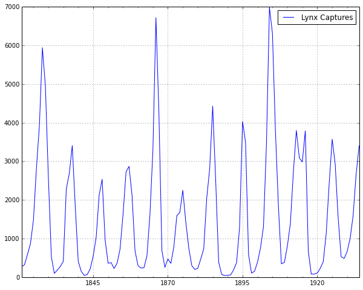

```python
lynx.plot(figsize(10,8))
```

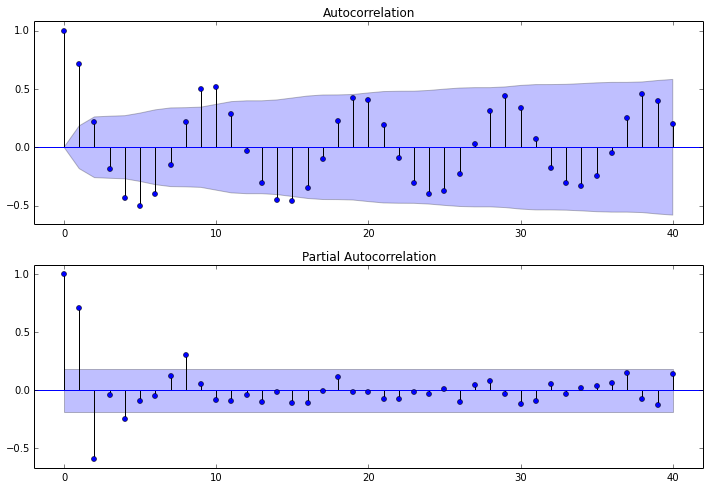

```python
fig = plt.figure(figsize=(12,8))
ax1 = fig.add_subplot(211)
fig = sm.graphics.tsa.plot_acf(lynx.values.squeeze(), lags=40, ax=ax1)
ax2 = fig.add_subplot(212)
fig = sm.graphics.tsa.plot_pacf(lynx, lags=40, ax=ax2)
```

```python
arma212 = sm.tsa.ARMA(lynx, (2,1,2)).fit()
print(arma212.params)
```

[output not shown]

```python
print(arma212.aic, arma212.bic, arma212.hqic)
```

```
1879.45889486 1893.1398871 1885.01124284
```

### Copy the parameter information into Excel for users to determine goodness-of-fit.

```python
Range('J2').value = "Akaide Information Criterion (AIC)"
Range('K2').value = arma212.aic

Range('J3').value = "Bayesian Information Criterion (BIC)"
Range('K3').value = arma212.bic

Range('J4').value = "Hannan-Quinn Information Criterion (HQIC)"
Range('K4').value = arma212.hqic
```

```python
sm.stats.durbin_watson(arma212.resid.values)
```

```
1.8611979321451435
```

### Add Durbin-Watson test result in Excel

```python
Range('J5').value = "Durbin-Watson test"
Range('K5').value = sm.stats.durbin_watson(arma212.resid.values)
```

### Copy residuals into Excel as a DataFrame. The original residuals object was an array, which is copied left-to-right by xlwings.

```python
arma_residual = DataFrame(arma212.resid.values)
```

```python
Range('M1').value = arma_residual
Range('N1').value = "Residuals"
```

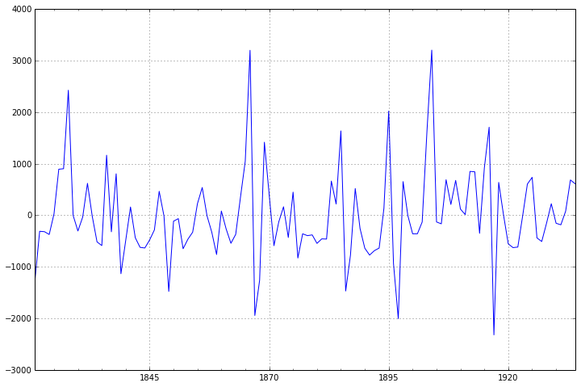

```python
fig = plt.figure(figsize=(12,8))
ax = fig.add_subplot(111)
ax = arma212.resid.plot(ax=ax)
```

```python
residual = arma212.resid
```

```python
stats.normaltest(residual)
```

```
(24.654724586496371, 4.4288867952103713e-06)
```

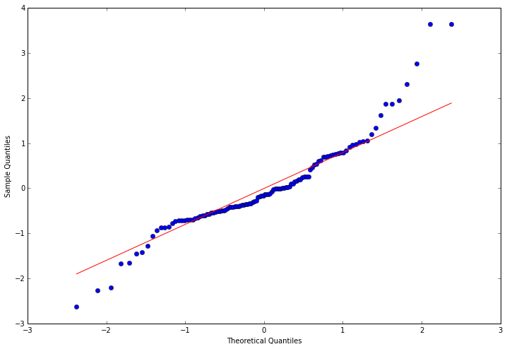

```python
fig = plt.figure(figsize=(12,8))
ax = fig.add_subplot(111)
fig = qqplot(residual, line='q', ax=ax, fit=True)
```

```python
r, q, p = sm.tsa.acf(residual.values.squeeze(), qstat=True)
data = np.c_[range(1,41), r[1:], q, p]
table = DataFrame(data, columns=['lag', "AC", "Q", "Prob(>Q)"])
print(table.set_index('lag'))
```

```
           AC          Q  Prob(>Q)
lag
1    0.058023   0.393990  0.530210
2   -0.197533   5.001068  0.082041
3    0.058472   5.408383  0.144222
4    0.080439   6.186253  0.185664
5    0.053773   6.537063  0.257407
6    0.000821   6.537146  0.365777
7   -0.215673  12.285847  0.091542
8   -0.020543  12.338495  0.136728
9    0.234537  19.266326  0.023021
10   0.151492  22.184491  0.014192
11  -0.076636  22.938518  0.018031
12  -0.066415  23.510393  0.023692
13  -0.123465  25.506261  0.019789
```

[output cut: 29 more lines]

### Copy lag, autocorrelation, and q values into Excel

```python
Range('P1').value = table
```

```python
insample_lynx = arma11.predict('1920', '1934', dynamic=True)
print(insample_lynx)
```

```
1920-12-31     662.524589
1921-12-31    1431.278917
1922-12-31    2025.348387
1923-12-31    2257.337222
1924-12-31    2138.469986
1925-12-31    1817.054967
1926-12-31    1479.802261
1927-12-31    1266.128436
1928-12-31    1225.987415
1929-12-31    1325.589390
1930-12-31    1484.966342
1931-12-31    1623.214668
1932-12-31    1691.117321
1933-12-31    1681.724714
1934-12-31    1620.993768
Freq: A-DEC, dtype: float64
```

### Copy the in-sample predicted values into Excel

```python
Range('V1').value = DataFrame(insample_lynx)
Range('W1').value = "Predicted In-Sample Values"
```

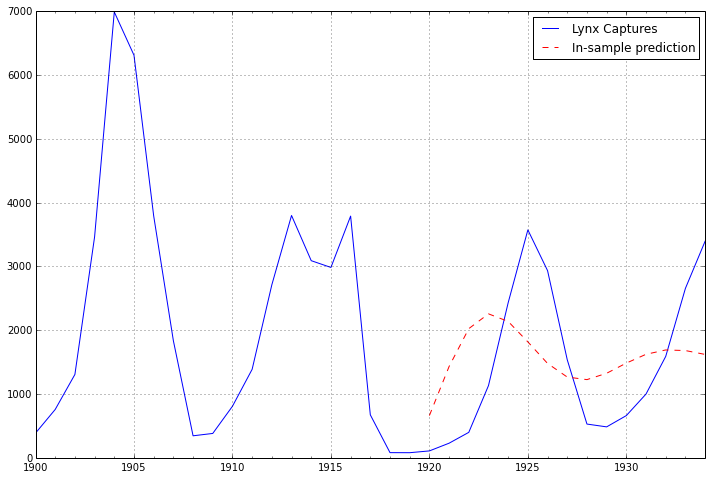

```python
ax = lynx.ix['1900':].plot(figsize=(12,8))
ax = insample_lynx.plot(ax=ax, style='r--', label="In-sample prediction");
ax.legend();
```

#### Initialize Excel line chart to add predicted values.

```python
Chart('Chart 4').set_source_data(Range('W2').vertical)
```

#### Since the predicted values are in sample, a more desired output would be to put the predicted values in the same chart as the observed; however, this functionality does not yet exist (that I know of) and would need to be done with a different package.

```python
def forecast_err(y, yh):
    return y.sub(yh).mean()
```

```python
error = forecast_err(lynx['Lynx Captures'], insample_lynx)
```

#### Enter forecast error into Excel

```python
Range('J6').value = "Average Forecast Error"
Range('K6').value = error
```

## Summary

#### The purpose of this notebook is to test a workflow to implement Python and Excel for better data analysis. Xlwings is a great tool for this workflow as it allows interaction between an IPython notebook and Excel. However, since it is relatively new and thus does not have as much functionality as other packages that have been around longer, it may be necessary to use packages such as xlwt/xlrt in development.

#### My next test for this workflow is to fully integrate the ARMA forecasting experiment with Excel. Due to Excel's saturation in the marketplace, and with the recent improvements in Excel 2013, I think there is great potential to use it as a front-end for better analytics built in Python and R.